# Técnica Bag of words para compreensão de estruturas e papéis de trabalhadores da indústria de óleo e gás

Código fonte, método e modelagem: Viviane Schneider. Método e validação: Aline Pacheco e Rosana Halinski De Oliveira

outubro de 2020 - última versão: 10 de dezembro de 2020

# 1 Contexto do estudo

Bases de dados que possuem dados de variáveis de resiliência em fatores humanos são notavelmente difíceis de encontrar na indústria de óleo e gás. A maioria das bases de dados disponíveis tratam da contagem dos acidentes e respectivos elementos subjacentes. Contudo, uma abordagem que investiga os condicionantes de performance que tornam um ambiente resiliênte é algo ainda novo na prevenção de acidentes nas plataformas de óleo e gás, e por esse motivo há escassez de dados estruturados com tal foco, contribuindo assim para que as análises orientadas à resiliência sejam um desafios aos pesquisadores.

## 1.1 Objetivos desse estudo

Tendo em vista a problemática apontada no contexto acima, este estudo visa o seguinte objetivo geral.

### 1.1.1 Objetivo geral

- Estabelecer um método para criar indicativos de capacidades resiliêntes a partir de dados textuais não estruturados.

Esses dados textuais são provenientes de narrações de colaboradores de plataformas offshore e onshore, da indústria de óleo e gás.

Os objetivos específicos para alcançar o objetivo geral é descrito a seguir

### 1.1.2 Objetivos específicos

1. Estabelecer um modelo de dados que permita estruturar os elementos textuais analisados, nomeando as falas dos entrevistados de acordo com o papel assumido por eles dentro da estrutura hierárquica no trabalho (representação por persona);
2. Avaliar as falas das personas para estimar as estruturas de poder estabelecidas a partir do termo “Comunicação”;
3. Descrever o perfil de cada persona, com base nos termos mais frequentes que eles relataram nos textos;
4. Verificar quais os termos mais frequentes utilizados por todas as personas, a fim de identificar os elementos símbólicos comum a todas as personas.

## 1.2 Questão de pesquisa

Como criar insumos para indicadores de capacidades resiliêntes a partir de dados textuais não estruturados?

## 1.3 Methods, Materials and Techniques

### 1.3.1 Métodos

Os métodos utilizados são provenientes do metamodelo descrito em Schneider(2019), na dimensão de avaliação “Senso de Unidade” da coerência da governança em ambientes complexos. Para avaliar o senso de unidade, o seguinte passo a passo foi realizado.

- Todas as falas transcritas nos documentos foram separadas em duas categorias, (i) pedidos: falas dos entrevistarores (pesquisadores HF); (ii) resposta: falas dos entrevistados.
- As falas dos entrevistados foram também categorizadas por personas. Personas são representações de perfis dos colaboradores da indústria de óleo e gás.

### 1.3.2 Materials

### 1.3.3 Técnicas

Para identificar os indicadores, neste estudo utilizou-se o método de mineração de texto “Bag of Words”. Segundo o glossário de Machine learning do Google*, essa técnica consistem em uma representação de palavras em uma frase ou passagem, independentemente da ordem.

Por exemplo, saco de palavras representa as seguintes três frases de forma idêntica:

- o cachorro pula
- pula o cachorro
- cachorro pula o

Cada palavra é mapeada para um índice em um vetor esparso, onde o vetor tem um índice para cada palavra do vocabulário. Por exemplo, a frase “o cachorro pula”" é mapeada em um vetor de característica com valores diferentes de zero nos três índices correspondentes às palavras o, cachorro e pula. O valor diferente de zero pode ser qualquer um dos seguintes:

- Um 1 para indicar a presença de uma palavra.
- Uma contagem do número de vezes que uma palavra aparece na bolsa.
- Algum outro valor, como o logaritmo da contagem do número de vezes que uma palavra aparece na bolsa.

*Disponível em: https://developers.google.com/machine-learning/glossary#b

# 2 Bibliotecas R

## 2.1 Lendo os arquivos

```
## Rows: 682
## Columns: 6
## $ ID_Fragmento        <dbl> 1, 2, 3, 4, 5, 6, 7, 8, 9, 10, 11, 12, 13, 14, ...
## $ Documento_Fragmento <dbl> 1, 1, 1, 1, 1, 1, 1, 1, 1, 1, 1, 1, 1, 1, 1, 1,...
## $ Persona             <dbl> 4, 1, 4, 1, 1, 2, 3, 4, 3, 1, 2, 4, 1, 4, 2, 4,...
## $ Tipo_Fragmento      <chr> "Pedido", "Resposta", "Pedido", "Resposta", "Re...
## $ Pessoa              <chr> "Fogaça", "Entrevistado 1", "Fogaça", "Entrevis...
## $ Texto               <chr> "Fogaça: então tá, tá gravando a partir de agor...
```

## 2.2 Função de limpeza do texto - (palavras que foram retiradas)

Essas são as palavras que foram retiradas dos textos.

```r
my_stops <- c("entrevistado", "entrevistada","fogaça",  "francisco", "Francisco", "Marina", "marina")
```

# 3 Avaliando os Pedidos dos entrevistadores

A avaliação dos perguntas dos entrevistadores em dinâmicas de storytelling é essencial, tendo em vista que o entrevistador provoca reações e repete as palavras dos entrevistados, com o intuito de confirmar o que foi relatado.

Assim, avaliar o conjunto de palavras e termos mais frequentes falados pelos entrevistadores, pode fornecer uma apanhado de conteúdo que foi relatado e confirmado nessas dinâmicas.

```
## [1] 1119  252
```

## 3.1 Palavras mais frequentes de Pedidos

Nesses resultados é possível verificar as palavras e agrupamentos mais frequentes nos pedidos dos entrevistadores

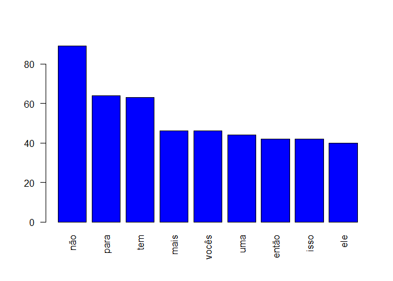

```
##   que   não  para   tem  mais vocês   uma então  isso   ele
##   192    89    64    63    46    46    44    42    42    40
```

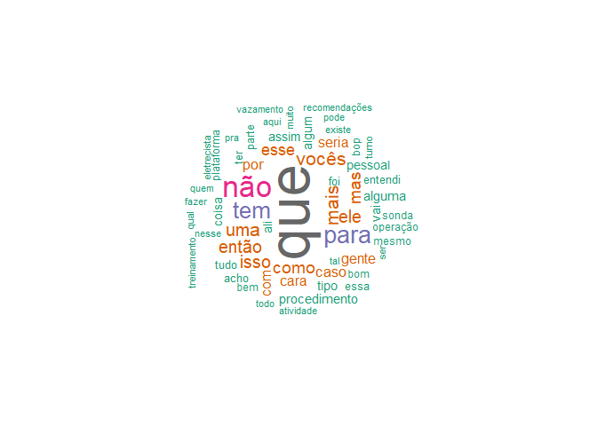

## 3.2 Clustering Pedido

O Dendograma abaixo mostra os principais termos dos repetidos pelos entrevistadores aos lideres e liderados.

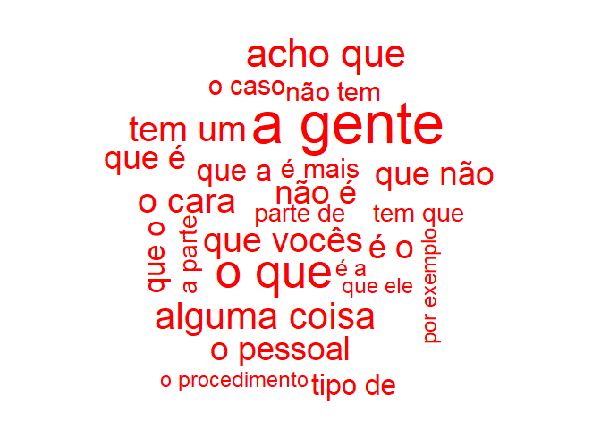

[figure not shown]

[figure not shown]

# 4 Avaliando as Respostas dos Líderes

Esse corpus agrega todas as falas dos entrevistados categorizados como líderes dos três documentos analisados.

Quantidade de falas e termos existentes ou não em cada fala:

```
## [1] 448  78
```

## 4.1 Palavras mais frequentes das respostas dos líderes

Nesses resultados é possível verificar as palavras e agrupamentos mais frequentes nos pedidos dos líderes

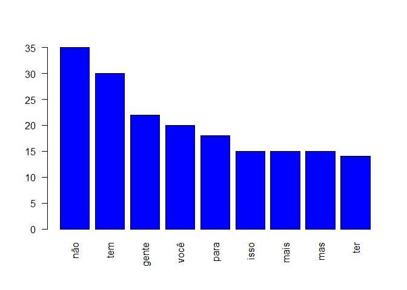

```
##   que   não   tem gente  você  para  isso  mais   mas   ter
##    74    35    30    22    20    18    15    15    15    14
```

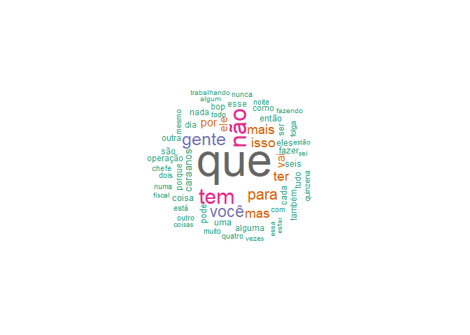

# 5 Avaliando as respostas dos liderados

Abaixo o conjunto de palavras mais frequentes dos liderados.

Quantidade de falas e termos existentes ou não em cada fala:

```
## [1] 508  77
```

## 5.1 Palavras mais frequentes dos liderados

Essas são as palavras mais frequentes faladas pelos liderados.

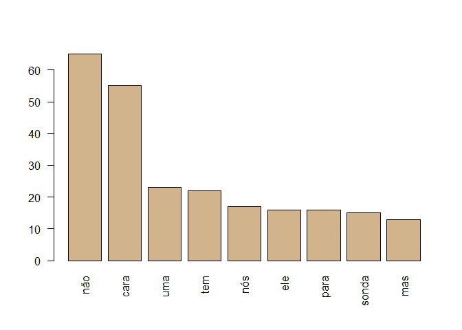

```
##   que   não  cara   uma   tem   nós   ele  para sonda   mas
##    84    65    55    23    22    17    16    16    15    13
```

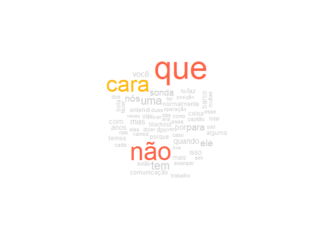

# 6 Palavras Comum Lideres e Liderados

```
## <<VCorpus>>
## Metadata:  corpus specific: 0, document level (indexed): 0
## Content:  documents: 2
```

## 6.1 Palavras comuns entre as personas

[output not shown]

[output cut: 15 more lines]

```
## <<VCorpus>>
## Metadata:  corpus specific: 0, document level (indexed): 0
## Content:  documents: 3
```

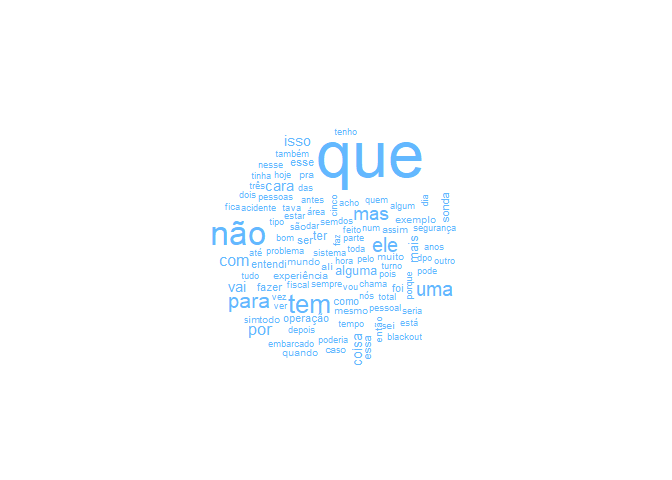

## 6.2 Núvem de palavras comuns entre Entrevistador, Gerentes e Operadores

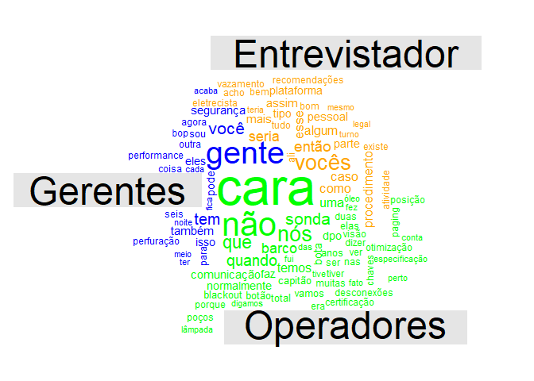

# 7 Conclusões

Observar cada parte de um corpus como sendo a representação de personas permite compreender os elementos simbólicos que povoam os modelos mentais dos agentes humanos, em contextos sociotécnicos. …

# 8 Referencias

http://www.stat.columbia.edu/~tzheng/files/Rcolor.pdf

https://eight2late.wordpress.com/2015/05/27/a-gentle-introduction-to-text-mining-using-r/

https://cran.r-project.org/web/packages/corpus/vignettes/corpus.html

https://rpubs.com/malkoves/DS_project